# 217974

*N* removed NAs: 3

*N* removed typo: 1

*N* removed <18: 27

*N* total clean: 119

| Group | *N* | *M*<sub>age</sub> | *M*<sub>rating</sub> |
| --- | --- | --- | --- |
| Control | 62 | 20.61 | 6.49 |
| Experim | 57 | 20.49 | 5.53 |

**Main analysis results**

*t*(117) = 6.58, *p* < .001

[interactive chart not shown]

[figure not shown]

[interactive chart not shown]

# 217974

Analysing Data, Spring 2020

[output not shown]

```
## Source: local data frame [119 x 8]
## Groups: <by row>
##
## # A tibble: 119 x 8
##    ID      AGE GROUP        QUESTION_1 QUESTION_2 QUESTION_3 composite_score Composite_score
##    <fct> <dbl> <fct>             <dbl>      <dbl>      <dbl>           <dbl>           <dbl>
##  1 BZAH     18 experimental          6          5          6            5.67            5.67
##  2 RIKW     22 experimental          6          6          4            5.33            5.33
##  3 XKQU     18 experimental          6          4          6            5.33            5.33
##  4 APCW     22 experimental          5          3          4            4               4
##  5 YZTE     19 experimental          6          6          6            6               6
##  6 FMII     26 experimental          8          5          7            6.67            6.67
##  7 LRLI     21 experimental          4          6          5            5               5
##  8 PCWZ     19 experimental          5          5          6            5.33            5.33
##  9 RWMC     18 experimental          7          4          5            5.33            5.33
## 10 NTES     23 experimental          4          5          6            5               5
## # ... with 109 more rows
```

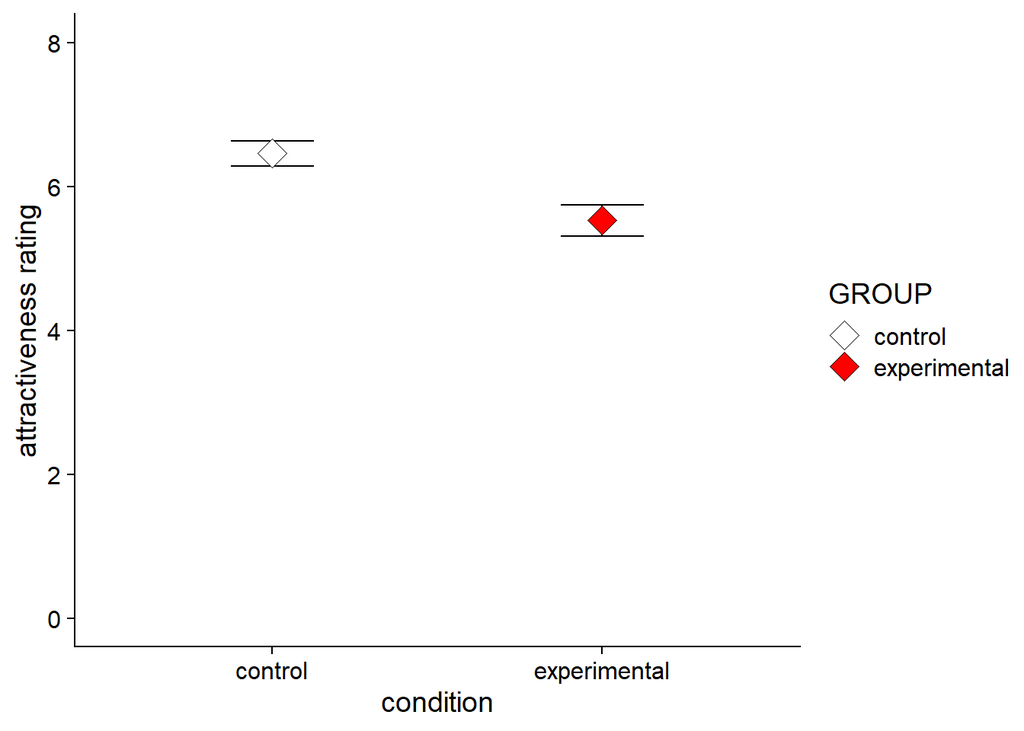

```
##
##  Two Sample t-test
##
## data:  composite_score by GROUP
## t = 6.5822, df = 117, p-value = 0.000000001374
## alternative hypothesis: true difference in means is not equal to 0
## 95 percent confidence interval:
##  0.6691177 1.2450494
## sample estimates:
##      mean in group control mean in group experimental
##                   6.489247                   5.532164
```

# Methods

## Design

Our hypothesis, and thus the hypothesis of the study being replicated by this study is: “red enhances women’s attraction to men” (Elliot et. al, 2010). The dependent variable was overall attraciveness by which the women scored the men on a 9 point rating scale. A score of 1 was low and meant the woman viewed the man as extremely unattractive while a score of 9 was extremely attractive. This rating was created by asking the women to consider: “How attractive do you think this person is?” “How pleasant is this person to look at?” and “If I were to meet the person in this picture face to face, I would think he is attractive.” (Elliot et.al, 2010) This rating, being numerical, was also classed as numerical data.

The men were viewed using black and white photos on a coloured background, and the colours of the background were the independent variables, being either red or white. This data was measured as 2 different factors. The red is clearly the main colour that is being tested but the white was used a control.

Considering all this, the operational alternative hypothesis for this particular study would be: on average, men on a red background should have a higher rating from the women, compared to the men on the white background.The null hypothesis would be that there is no correlation between the red and white backgrounds and the mean attractiveness ratings, however, our prediction is that the alternative hypothesis will prove to be true.

The statistical test that will be used to investigate this hypothesis is a two sample t test as we are only measuring the white control variable against the red independent variable.

# Results

There seems to be a significant difference in mean composite scores for attractiveness as suggested by the T-test we said was to be conducted earlier. The difference of a whole attractive point on average suggests there could be some sort of relationship, but it seems to be the opposite relationship to what was first expected. It can be inferred from this data set that white actually proved to be the more arousing colour background for women.

# Discussion

The results indicate that in fact, the red background condition reduced the percieved attractiveness of the men in the pictures, compared to the control variable of the men in pictures in white backgrounds by around 1 attractiveness rating. This seems to both contradict our orginal predictions and the results of the (Elliot et.al, 2010) study that this study replicated. In the original study, women percieved men in red backgrounds as clearly more attrative than those of the control group but that effect seems not to have been replicated here. This could either mean that this effect isnt as strong or consistent across the wider population as Elliot first thought, or it could simply be due to a lack of access to a huge sample size in this study.

However, this replication is supported by the findings of (Peperkoorn et.al, 2016) as this study also failed to produce empirical evidence supporting the red effect. “An independent samples t-test indicated no effect of color on men’s ratings of sexual receptivity” (peperkoorn et.al, 2016). This could mean that Elliot’s original study really isn’t replicable and the red effect of the colour increasing women’s attraction to men may even be false.

This topic should be investigated further, firstly to see just how widespread the effect is, by using a larger sample size and perhaps using homosexual men as well as women to score the men, to investigate whether the effect is exclusively applicable to women’s perception of men. It could also be worth using red versus white clothes instead of backgrounds to make the study more ecologically valid. Another useful further study is to see if this effect is truly applicable to marketing for clothes brands, by launching a specific marketing campaign to compare how the same red men’s clothes versus white clothes shown off on the same model, and investigating if there’s a signifcant difference in number of purchases or money made for each colour of clothes. These further investigations are not only extremely interesting, but could also have a major impact on fashion and modeling agencies around the world.

One potential limitation of this study is that the sample size could be improved upon as only 119 participants’ worth of usable data isn’t much when attempting to generalise a specific phenomenon to the broader population. 1500 participants for example, would be a much more suitable number, but admittedly this would clearly be more costly and require more funding.

A further limitation of the study would be that the sample population used was only undergraduates from England, meaning that this sample could risk ethnocentrism if the results and conclusions from the study were applied to more than just western culture. In addition the ages of most participants included were fairly young as undergraduates were used, making the study potentially more unrepresentitive. The conclusions drawn from the study wouldn’t reflect the attraction of older people who may find different traits or physical qualties more arousing, meaning the results of this study may not be applicable to them.

However one key strength of this study is that the final composite scores used were likely a good represtentation of the women’s overall attraction to each man as it assessed this attraction in 3 seperate measures or scores. This is a good way to overcome or at least reduce the possibility of individual differences undermining the validity and reliabilty of the study, as it makes the final ratings more comparible and in theory more replicable.

In conclusion, it seems that this replication study does not support the red effect and thus our hypothesis that “red enhances women’s attraction to men” is seemingly not true and this suggests that Elliot’s original study stating this effect to be true could in fact be flawed.

# References

Elliot, A. J., Kayser, D. N., Greitemeyer, T., Lichtenfeld, S., Gramzow, R. H., Maier, M. A., & Liu, H. (2010). Red, rank, and romance in women viewing men. Journal of Experimental Psychology: General, 139(3), 399–417.

Peperkoorn, L. S., Roberts, S. C., & Pollet, T. V. (2016). Revisiting the red effect on attractiveness and sexual receptivity: No effect of the color red on human mate preferences. Evolutionary Psychology, 14(4), 1474704916673841.